# MIS40970 Data Mining - Assignment 3 Classification

## **Q6 Install R package “caret”. Import German credit rating dataset (GermanCredit). Examine the data. Use the data to build a classification model to predict “Good” or “Bad” customer credit rating. Pay attention to the model’s generalisation and its’ ability to correctly predict both classes. Interpret the results.**

```r
#Installing Caret package
install.packages("caret")
library(caret)
```

```r
#Importing dataset GermanCredit
data("GermanCredit")
print("Summary of German Credit")
```

```
[1] "Summary of German Credit"
```

```r
cat("\n")
```

```r
str(GermanCredit)
```

```
'data.frame':   1000 obs. of  62 variables:
 $ Duration                              : int  6 48 12 42 24 36 24 36 12 30 ...
 $ Amount                                : int  1169 5951 2096 7882 4870 9055 2835 6948 3059 5234 ...
 $ InstallmentRatePercentage             : int  4 2 2 2 3 2 3 2 2 4 ...
 $ ResidenceDuration                     : int  4 2 3 4 4 4 4 2 4 2 ...
 $ Age                                   : int  67 22 49 45 53 35 53 35 61 28 ...
 $ NumberExistingCredits                 : int  2 1 1 1 2 1 1 1 1 2 ...
 $ NumberPeopleMaintenance               : int  1 1 2 2 2 2 1 1 1 1 ...
 $ Telephone                             : num  0 1 1 1 1 0 1 0 1 1 ...
 $ ForeignWorker                         : num  1 1 1 1 1 1 1 1 1 1 ...
 $ Class                                 : Factor w/ 2 levels "Bad","Good": 2 1 2 2 1 2 2 2 2 1 ...
 $ CheckingAccountStatus.lt.0            : num  1 0 0 1 1 0 0 0 0 0 ...
 $ CheckingAccountStatus.0.to.200        : num  0 1 0 0 0 0 0 1 0 1 ...
 $ CheckingAccountStatus.gt.200          : num  0 0 0 0 0 0 0 0 0 0 ...
 $ CheckingAccountStatus.none            : num  0 0 1 0 0 1 1 0 1 0 ...
```

[output cut: 48 more lines]

```r
#Creating Trained and test dataset
set.seed(123)
GermanCredit <- GermanCredit[,!names(GermanCredit) %in% c("Duration","Amount","account_length")]
partition <- sample(2,nrow(GermanCredit),replace = TRUE,prob = c(0.7,0.3))
trainGC <- GermanCredit[partition ==1,]
testGC <- GermanCredit[partition ==2,]
cat("\n \n \n")
```

```r
print("Summary of dataset")
```

```
[1] "Summary of dataset"
```

```r
cat("\n")
```

```r
summary(GermanCredit)
```

```
 InstallmentRatePercentage ResidenceDuration      Age
 Min.   :1.000             Min.   :1.000     Min.   :19.00
 1st Qu.:2.000             1st Qu.:2.000     1st Qu.:27.00
 Median :3.000             Median :3.000     Median :33.00
 Mean   :2.973             Mean   :2.845     Mean   :35.55
 3rd Qu.:4.000             3rd Qu.:4.000     3rd Qu.:42.00
 Max.   :4.000             Max.   :4.000     Max.   :75.00
 NumberExistingCredits NumberPeopleMaintenance   Telephone
 Min.   :1.000         Min.   :1.000           Min.   :0.000
 1st Qu.:1.000         1st Qu.:1.000           1st Qu.:0.000
 Median :1.000         Median :1.000           Median :1.000
 Mean   :1.407         Mean   :1.155           Mean   :0.596
 3rd Qu.:2.000         3rd Qu.:1.000           3rd Qu.:1.000
 Max.   :4.000         Max.   :2.000           Max.   :1.000
 ForeignWorker    Class     CheckingAccountStatus.lt.0
 Min.   :0.000   Bad :300   Min.   :0.000
 1st Qu.:1.000   Good:700   1st Qu.:0.000
 Median :1.000              Median :0.000
 Mean   :0.963              Mean   :0.274
 3rd Qu.:1.000              3rd Qu.:1.000
 Max.   :1.000              Max.   :1.000
 CheckingAccountStatus.0.to.200 CheckingAccountStatus.gt.200
 Min.   :0.000                  Min.   :0.000
 1st Qu.:0.000                  1st Qu.:0.000
 Median :0.000                  Median :0.000
 Mean   :0.269                  Mean   :0.063
 3rd Qu.:1.000                  3rd Qu.:0.000
 Max.   :1.000                  Max.   :1.000
 CheckingAccountStatus.none CreditHistory.NoCredit.AllPaid
 Min.   :0.000              Min.   :0.00
 1st Qu.:0.000              1st Qu.:0.00
 Median :0.000              Median :0.00
 Mean   :0.394              Mean   :0.04
 3rd Qu.:1.000              3rd Qu.:0.00
 Max.   :1.000              Max.   :1.00
 CreditHistory.ThisBank.AllPaid CreditHistory.PaidDuly CreditHistory.Delay
 Min.   :0.000                  Min.   :0.00           Min.   :0.000
 1st Qu.:0.000                  1st Qu.:0.00           1st Qu.:0.000
 Median :0.000                  Median :1.00           Median :0.000
 Mean   :0.049                  Mean   :0.53           Mean   :0.088
```

[output cut: 113 more lines]

```
 Max.   :1.000   Max.   :1.000   Max.   :1.000
 Job.UnskilledResident Job.SkilledEmployee
 Min.   :0.0           Min.   :0.00
 1st Qu.:0.0           1st Qu.:0.00
 Median :0.0           Median :1.00
 Mean   :0.2           Mean   :0.63
 3rd Qu.:0.0           3rd Qu.:1.00
 Max.   :1.0           Max.   :1.00
 Job.Management.SelfEmp.HighlyQualified
 Min.   :0.000
 1st Qu.:0.000
 Median :0.000
 Mean   :0.148
 3rd Qu.:0.000
 Max.   :1.000
```

```r
print("Printing dimensions of Trained and Test dataset created")
```

```
[1] "Printing dimensions of Trained and Test dataset created"
```

```r
print("_________________________Train Dataset_________________")
```

```
[1] "_________________________Train Dataset_________________"
```

```r
dim(trainGC)
```

```
[1] 705  60
```

```r
print("_________________________Test  Dataset_________________")
```

```
[1] "_________________________Test  Dataset_________________"
```

```r
dim(testGC)
```

```
[1] 295  60
```

```r
library(tree)
#Unprunned dataset of GermanCredit
unp_fit = tree(trainGC$Class~.,trainGC)
print("Summary of classification of German Credit")
```

```
[1] "Summary of classification of German Credit"
```

```r
cat("\n")
```

```r
summary(unp_fit)
```

```
Classification tree:
tree(formula = trainGC$Class ~ ., data = trainGC)
Variables actually used in tree construction:
[1] "CheckingAccountStatus.none"     "CreditHistory.NoCredit.AllPaid"
[3] "CheckingAccountStatus.lt.0"     "CreditHistory.Critical"
[5] "Housing.Own"                    "OtherInstallmentPlans.Bank"
Number of terminal nodes:  7
Residual mean deviance:  1.017 = 709.7 / 698
Misclassification error rate: 0.2511 = 177 / 705
```

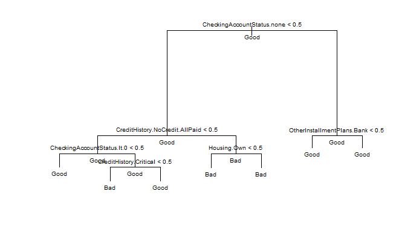

```r
plot(unp_fit)
text(unp_fit,all=TRUE,cex = 0.6)
```

```r
#Confusion Matrix
pGC = predict(unp_fit,trainGC,type = "class")
p_table = table(pGC, trainGC$Class)
print(p_table)
```

```
pGC    Bad Good
  Bad   92   62
  Good 115  436
```

```r
confusionMatrix(p_table)
```

```
Confusion Matrix and Statistics


pGC    Bad Good
  Bad   92   62
  Good 115  436

               Accuracy : 0.7489
                 95% CI : (0.7152, 0.7806)
    No Information Rate : 0.7064
    P-Value [Acc > NIR] : 0.006747

                  Kappa : 0.3458
 Mcnemar's Test P-Value : 9.285e-05

            Sensitivity : 0.4444
            Specificity : 0.8755
         Pos Pred Value : 0.5974
         Neg Pred Value : 0.7913
             Prevalence : 0.2936
         Detection Rate : 0.1305
   Detection Prevalence : 0.2184
      Balanced Accuracy : 0.6600

       'Positive' Class : Bad
```

```r
pGC1 = predict(unp_fit,testGC,type = "class")
p1_table = table(pGC1, testGC$Class)
print(p1_table)
```

```
pGC1   Bad Good
  Bad   38   35
  Good  55  167
```

```r
print("Confusion Matrix for test German Credit dataset")
```

```
[1] "Confusion Matrix for test German Credit dataset"
```

```r
cat("\n")
```

```r
confusionMatrix(p1_table)
```

```
Confusion Matrix and Statistics


pGC1   Bad Good
  Bad   38   35
  Good  55  167

               Accuracy : 0.6949
                 95% CI : (0.6389, 0.747)
    No Information Rate : 0.6847
    P-Value [Acc > NIR] : 0.3797

                  Kappa : 0.2498
 Mcnemar's Test P-Value : 0.0452

            Sensitivity : 0.4086
            Specificity : 0.8267
         Pos Pred Value : 0.5205
         Neg Pred Value : 0.7523
             Prevalence : 0.3153
         Detection Rate : 0.1288
   Detection Prevalence : 0.2475
      Balanced Accuracy : 0.6177

       'Positive' Class : Bad
```

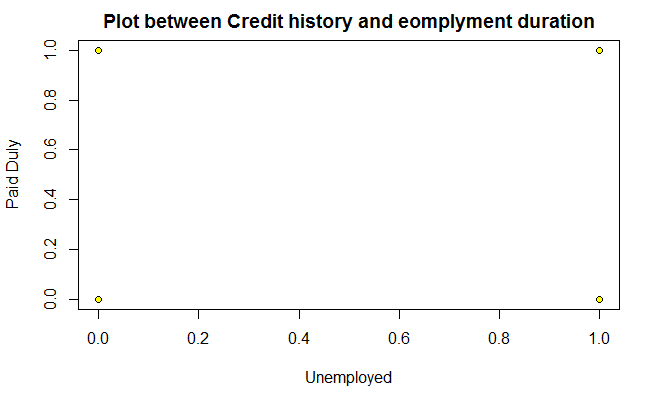

```r
plot(trainGC$CreditHistory.PaidDuly~trainGC$EmploymentDuration.Unemployed,pch=21,main="Plot between Credit history and eomplyment duration",xlab="Unemployed", ylab ="Paid Duly",bg=c("green","yellow") [unclass(trainGC$Class)])
```

```r
#Pruned tree
cv_German=cv.tree(unp_fit,FUN=prune.misclass)
print(cv_German)
```

```
$size
[1] 7 5 1

$dev
[1] 202 202 217

$k
[1] -Inf  0.0  7.5

$method
[1] "misclass"

attr(,"class")
[1] "prune"         "tree.sequence"
```

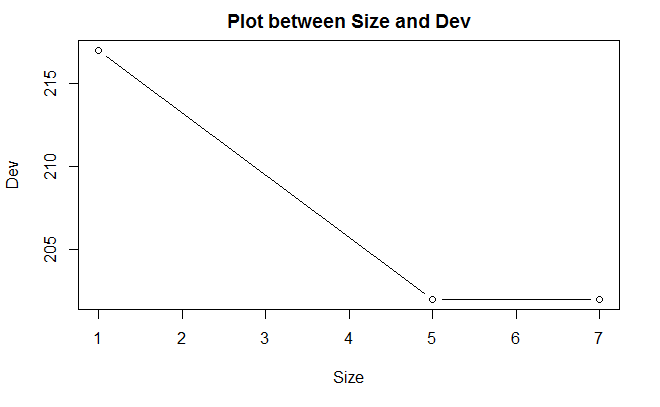

```r
 plot(cv_German$size,cv_German$dev,type="b",xlab = "Size",ylab = "Dev",main = "Plot between Size and Dev")
```

```r
prune_GC = prune.misclass(unp_fit,best=2)
summary(prune_GC)
```

```
Classification tree:
snip.tree(tree = unp_fit, nodes = c(3L, 5L))
Variables actually used in tree construction:
[1] "CheckingAccountStatus.none"     "CreditHistory.NoCredit.AllPaid"
[3] "CheckingAccountStatus.lt.0"     "CreditHistory.Critical"
Number of terminal nodes:  5
Residual mean deviance:  1.044 = 731.1 / 700
Misclassification error rate: 0.2511 = 177 / 705
```

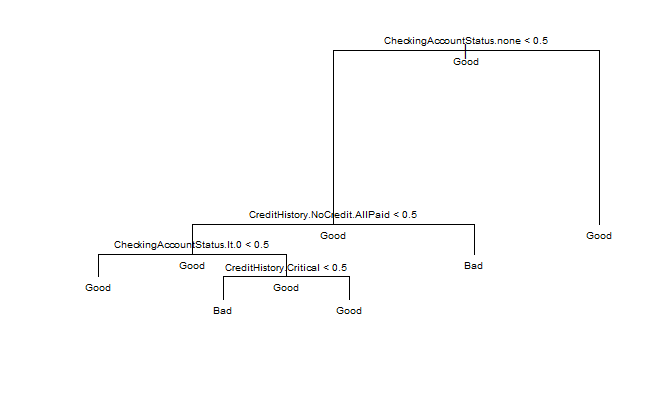

```r
plot(prune_GC)
text(prune_GC,all=TRUE,cex = 0.6)
```

As from the summary results of pruned and unpruned decision tree, we can see that Misclassification error rate is same for both the tree types. However, residual mean deviance is larger and unpruned tree is better fit and helps in understanding more than pruned tree.

## **Q7 Load file college.csv provided on Blackboard. Explore the data. Prepare the data for analysis. Use three different classification algorithms to classify colleges into two classes based on the label (“Not Elite”, “Elite”) (at least one algorithm of the type decision tree). 1. Describe what you have learned about the dataset and classification results. 2. What classification algorithm(s) did you use, with what parameter settings and how these settings affected the algorithm(s) performance? 3. Exclude the class labels from the data and explore this dataset with clustering. Compare clustering results with results of classification.**

```r
library(readr)
cdata <- read_csv("G:/R_programs_git/R_Progams/Classification/Classification/college.csv", col_types = cols(Private = col_factor(levels = c("Yes","No")), isElite = col_factor(levels = c("Elite","Not Elite"))), na = "0")
View(cdata)
```

Now we will ue descriptive analytics to understand insights about dataset College (cdata).

```r
cat("\n \n")
```

```r
print("Summary of dataset")
```

```
[1] "Summary of dataset"
```

```r
cat("\n")
```

```r
summary(cdata)
```

```
       X1          name            accept_rate        Outstate
 Min.   :  1   Length:777         Min.   :0.1545   Min.   : 2340
 1st Qu.:195   Class :character   1st Qu.:0.6756   1st Qu.: 7320
 Median :389   Mode  :character   Median :0.7788   Median : 9990
 Mean   :389                      Mean   :0.7469   Mean   :10441
 3rd Qu.:583                      3rd Qu.:0.8485   3rd Qu.:12925
 Max.   :777                      Max.   :1.0000   Max.   :21700
     Enroll       Grad.Rate      Private        isElite
 Min.   :  35   Min.   : 10.00   Yes:565   Elite    : 78
 1st Qu.: 242   1st Qu.: 53.00   No :212   Not Elite:699
 Median : 434   Median : 65.00
 Mean   : 780   Mean   : 65.46
 3rd Qu.: 902   3rd Qu.: 78.00
 Max.   :6392   Max.   :118.00
```

```r
cat("\n \n")
```

```r
print("Attributes of dataset")
```

```
[1] "Attributes of dataset"
```

```r
cat("\n")
```

```r
attributes(cdata)
```

```
$class
[1] "tbl_df"     "tbl"        "data.frame"

$row.names
  [1]   1   2   3   4   5   6   7   8   9  10  11  12  13  14  15  16  17  18
 [19]  19  20  21  22  23  24  25  26  27  28  29  30  31  32  33  34  35  36
 [37]  37  38  39  40  41  42  43  44  45  46  47  48  49  50  51  52  53  54
 [55]  55  56  57  58  59  60  61  62  63  64  65  66  67  68  69  70  71  72
 [73]  73  74  75  76  77  78  79  80  81  82  83  84  85  86  87  88  89  90
 [91]  91  92  93  94  95  96  97  98  99 100 101 102 103 104 105 106 107 108
[109] 109 110 111 112 113 114 115 116 117 118 119 120 121 122 123 124 125 126
[127] 127 128 129 130 131 132 133 134 135 136 137 138 139 140 141 142 143 144
[145] 145 146 147 148 149 150 151 152 153 154 155 156 157 158 159 160 161 162
[163] 163 164 165 166 167 168 169 170 171 172 173 174 175 176 177 178 179 180
[181] 181 182 183 184 185 186 187 188 189 190 191 192 193 194 195 196 197 198
```

[output cut: 39 more lines]

```r
print("Summary of isElite column")
```

```
[1] "Summary of isElite column"
```

```r
cat("\n")
```

```r
summary(cdata$isElite)
```

```
    Elite Not Elite
       78       699
```

From summary table of descriptive analytics we can know the basic statistics such as mean,median, range, etc. We can generate the summary table by two ways as discussed below :

```r
df <- unique(cdata[c(3:6)])
Des_stats <- do.call(data.frame,
                    list(Average = apply(df, 2, mean),
                    Standard_Deviation = apply(df, 2, sd),
                    Median = apply(df, 2, median),
                    Minimum = apply(df, 2, min),
                    Maximum = apply(df, 2, max)))
print(Des_stats)
```

|  | Average | Standard_Deviation | Median | Minimum | Maximum |
| --- | --- | --- | --- | --- | --- |
| accept_rate | 7.469277e-01 | 0.1471039 | 0.77875 | 0.1544863 | 1 |
| Outstate | 1.044067e+04 | 4023.0164841 | 9990.00000 | 2340.0000000 | 21700 |
| Enroll | 7.799730e+02 | 929.1761901 | 434.00000 | 35.0000000 | 6392 |
| Grad.Rate | 6.546332e+01 | 17.1777099 | 65.00000 | 10.0000000 | 118 |

To see more details we can generate correlation methods so that we can establish the mutual relationship amongst variables and we can forsee the trends among different variables. Correlation plot can be generated by creating scatterplot matrix. There are two methods through which we can generate a scatterplot matrix described as follow:

```r
corr = cor(df,use = "complete.obs",method="kendall")
print(round(corr,digits = 3))
```

```
            accept_rate Outstate Enroll Grad.Rate
accept_rate       1.000   -0.086 -0.169    -0.158
Outstate         -0.086    1.000 -0.056     0.420
Enroll           -0.169   -0.056  1.000     0.065
Grad.Rate        -0.158    0.420  0.065     1.000
```

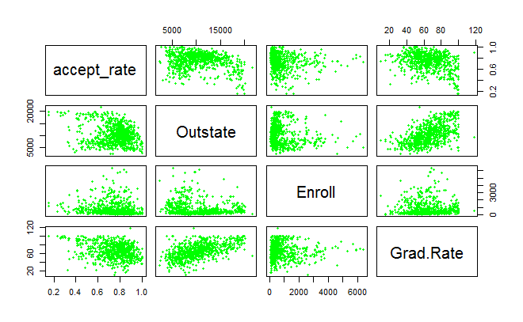

```r
library(s20x)
pairs(df,col="green",pch=20)
```

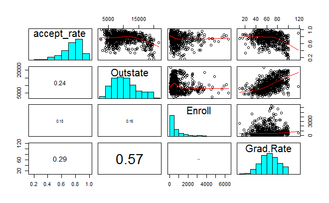

```r
pairs20x(df)
```

Before applying classification algorithm to any dataset, first we need to create reusable partitions.

```r
set.seed(8)
set <- cdata[-2]
partitiondata <- sample(2, nrow(set),replace=TRUE,prob=c(0.7,0.3))
trainData <- set[partitiondata ==1,]
testData <- set[partitiondata ==2,]
print("Train Data")
```

```
[1] "Train Data"
```

```r
dim(trainData)
```

```
[1] 543   7
```

```r
cat("\n")
```

```r
print("Test Data")
```

```
[1] "Test Data"
```

```r
dim(testData)
```

```
[1] 234   7
```

By using histograms and density curve, we can interpret the distribution of the demographic and competitive variables whether the distribution is normal distribution or not.

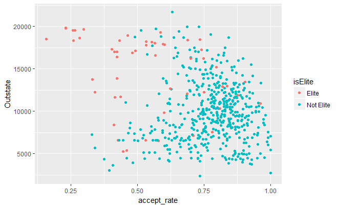

```r
qplot(accept_rate, Outstate, colour=isElite, data=trainData)
par(mfrow=c(1,2))
```

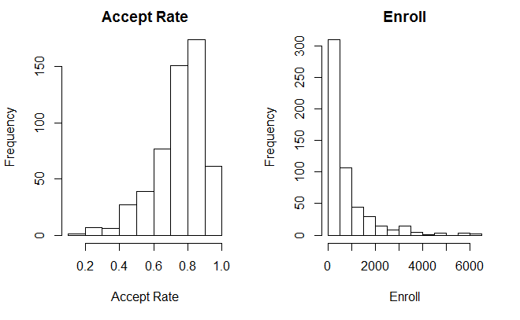

```r
hist(trainData$accept_rate, main = "Accept Rate",xlab = "Accept Rate")
hist(trainData$Enroll, main = "Enroll",xlab = "Enroll")
```

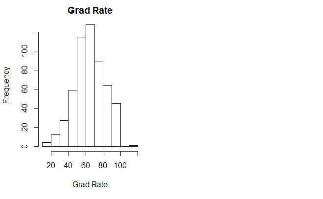

```r
hist(trainData$Grad.Rate, main = "Grad Rate",xlab = "Grad Rate")
hist(trainData$Outstate, main="Outstate",xlab = "Outstate")
```

**Classification using Tree**

```r
library(tree)

tree.trainData = tree(trainData$isElite~.,trainData)
print("Summary of tree using TREE")
cat("\n")
summary(tree.trainData)
```

[output not shown]

```r
plot(tree.trainData)
text(tree.trainData, all = TRUE, cex = 0.45)
```

[output not shown]

```r
#Confusion Matrix of trained data
confusionMatrix(table(predict(tree.trainData,trainData,type = "class"),trainData$isElite))
```

```r
#Confusion Matrix of test data
confusionMatrix(table(predict(tree.trainData,testData,type = "class"),testData$isElite))
```

[output not shown]

```r
plot(trainData$Enroll~trainData$Grad.Rate,pch=21,main="Plot between Grad Rate and Enroll",xlab = "Grad Rate",ylab = "Enroll", bg=c("green","red","yellow")[unclass(trainData$isElite)])

plot(trainData$accept_rate~trainData$Outstate,pch=21,main="Plot between Accept Rate and Outstate",xlab = "Outstate",ylab = "Accept Rate", bg=c("green","red","yellow")[unclass(trainData$isElite)])
```

[output not shown]

```r
#Pruned Data

p.tree = prune.misclass(tree.trainData,best=2)
print("Summary of pruned decision tree with best 2")
summary(p.tree)
```

[output not shown]

```r
plot(p.tree)
text(p.tree, all=TRUE, cex = 0.8)
```

[output not shown]

```r
#Confusion Matrix of train data of pruned tree
confusionMatrix(table(predict(p.tree,trainData,type = "class"),trainData$isElite))
```

```r
#Confusion Matrix of test data of pruned tree
confusionMatrix(table(predict(p.tree,testData,type = "class"),testData$isElite))
```

[output not shown]

```r
cv1=cv.tree(tree.trainData,FUN=prune.misclass)
par(mfrow=c(1,2))
plot(cv1$size,cv1$dev,type="b",xlab = "Size",ylab = "Dev",main = "Plot Dev vs Size")

par(mfrow=c(1,2))
plot(cv1$k,cv1$dev,type="b",xlab = "K",ylab = "Dev",main = "Plot K vs Size")
```

[output not shown]

**Random Forest Classification**

```r
library(randomForest)
random.tree <- randomForest(isElite~.,data=trainData, importance = TRUE,tree=2500)
print(random.tree)
```

```
Call:
 randomForest(formula = isElite ~ ., data = trainData, importance = TRUE,      tree = 2500)
               Type of random forest: classification
                     Number of trees: 500
No. of variables tried at each split: 2

        OOB estimate of  error rate: 5.71%
Confusion matrix:
          Elite Not Elite class.error
Elite        27        26  0.49056604
Not Elite     5       485  0.01020408
```

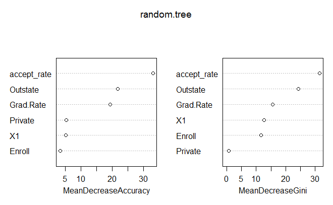

```r
varImpPlot(random.tree)
```

```r
pdata <- predict(random.tree, testData)
print("Summary of prediction data")
```

```
[1] "Summary of prediction data"
```

```r
summary(pdata)
```

```
    Elite Not Elite
       16       218
```

```r
cat("\n")
```

```r
print("Summary of isElite")
```

```
[1] "Summary of isElite"
```

```r
summary(testData$isElite)
```

```
    Elite Not Elite
       25       209
```

```r
cat("\n\n")
```

```r
confusionMatrix(table(pdata,testData$isElite))
```

```
Confusion Matrix and Statistics


pdata       Elite Not Elite
  Elite        12         4
  Not Elite    13       205

               Accuracy : 0.9274
                 95% CI : (0.8862, 0.9571)
    No Information Rate : 0.8932
    P-Value [Acc > NIR] : 0.05071

                  Kappa : 0.5476
 Mcnemar's Test P-Value : 0.05235

            Sensitivity : 0.48000
            Specificity : 0.98086
         Pos Pred Value : 0.75000
         Neg Pred Value : 0.94037
             Prevalence : 0.10684
         Detection Rate : 0.05128
   Detection Prevalence : 0.06838
      Balanced Accuracy : 0.73043

       'Positive' Class : Elite
```

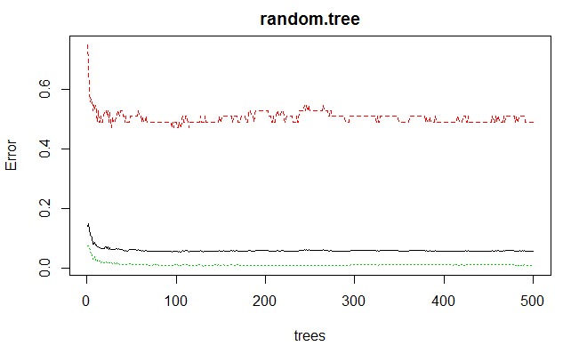

```r
plot(random.tree)
```

```r
importance(random.tree)
```

```
                 Elite Not Elite MeanDecreaseAccuracy MeanDecreaseGini
X1           3.4312992  4.075564             5.084996       12.6509341
accept_rate 38.1722712 17.360746            33.103015       31.4672422
Outstate    19.3027137 15.353271            21.736859       24.2635420
Enroll       2.9347257  2.184605             3.299481       11.7506522
Grad.Rate   19.1956900 11.150160            19.401433       15.5854682
Private      0.8796058  4.993895             5.233549        0.7497948
```

```r
library(party)
set.seed(1234)
r.tree <- cforest(as.factor(isElite) ~ .,data=trainData, controls=cforest_unbiased(ntree=200,mtry=3))
prediction <- predict(r.tree,testData,OOB = TRUE,type="response")
summary(prediction)
```

```
    Elite Not Elite
       15       219
```

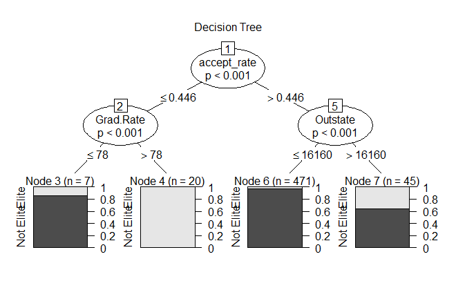

```r
temp <- ctree(trainData$isElite~.,data=trainData)
plot(temp,main = "Decision Tree",cex = 0.5)
```

**Classification using Regression**

```r
library(rpart)
set.seed(145)
rp.tree <- rpart(isElite~.,data=trainData)
print("Summary of rpart decision tree")
```

```
[1] "Summary of rpart decision tree"
```

```r
cat("\n\n")
```

```r
summary(rp.tree)
```

```
Call:
rpart(formula = isElite ~ ., data = trainData)
  n= 543

          CP nsplit rel error    xerror      xstd
1 0.28301887      0 1.0000000 1.0000000 0.1304849
2 0.09433962      1 0.7169811 0.9245283 0.1259754
3 0.04716981      2 0.6226415 0.8490566 0.1212119
4 0.01000000      4 0.5283019 0.6981132 0.1107899

Variable importance
accept_rate    Outstate   Grad.Rate      Enroll     Private
         53          25          16           3           2

Node number 1: 543 observations,    complexity param=0.2830189
  predicted class=Not Elite  expected loss=0.09760589  P(node) =1
    class counts:    53   490
   probabilities: 0.098 0.902
  left son=2 (27 obs) right son=3 (516 obs)
  Primary splits:
      accept_rate < 0.4458624 to the left,  improve=26.289430, (0 missing)
      Outstate    < 16180     to the right, improve=21.029030, (0 missing)
      Grad.Rate   < 88.5      to the right, improve=13.679000, (0 missing)
      Enroll      < 1080      to the right, improve= 3.059383, (0 missing)
      X1          < 590       to the right, improve= 1.357474, (0 missing)
  Surrogate splits:
      Outstate < 19519     to the right, agree=0.952, adj=0.037, (0 split)

Node number 2: 27 observations,    complexity param=0.09433962
  predicted class=Elite      expected loss=0.2222222  P(node) =0.04972376
    class counts:    21     6
   probabilities: 0.778 0.222
  left son=4 (20 obs) right son=5 (7 obs)
  Primary splits:
      Grad.Rate < 79        to the right, improve=7.619048, (0 missing)
      Outstate  < 7830      to the right, improve=6.333333, (0 missing)
      Enroll    < 884       to the right, improve=2.871795, (0 missing)
      X1        < 258       to the left,  improve=1.568627, (0 missing)
      Private   splits as  LR, improve=1.333333, (0 missing)
  Surrogate splits:
```

[output cut: 42 more lines]

```

Node number 7: 471 observations
  predicted class=Not Elite  expected loss=0.03397028  P(node) =0.8674033
    class counts:    16   455
   probabilities: 0.034 0.966

Node number 12: 17 observations
  predicted class=Elite      expected loss=0.3529412  P(node) =0.03130755
    class counts:    11     6
   probabilities: 0.647 0.353

Node number 13: 28 observations
  predicted class=Not Elite  expected loss=0.1785714  P(node) =0.05156538
    class counts:     5    23
   probabilities: 0.179 0.821
```

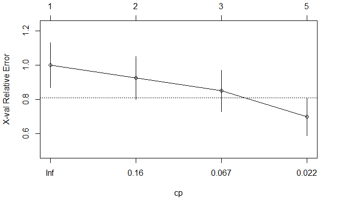

```r
plotcp(rp.tree)
```

```r
cat("\n")
```

```r
printcp(rp.tree)
```

```
Classification tree:
rpart(formula = isElite ~ ., data = trainData)

Variables actually used in tree construction:
[1] accept_rate Grad.Rate   Outstate

Root node error: 53/543 = 0.097606

n= 543

       CP nsplit rel error  xerror    xstd
1 0.28302      0   1.00000 1.00000 0.13048
2 0.09434      1   0.71698 0.92453 0.12598
3 0.04717      2   0.62264 0.84906 0.12121
4 0.01000      4   0.52830 0.69811 0.11079
```

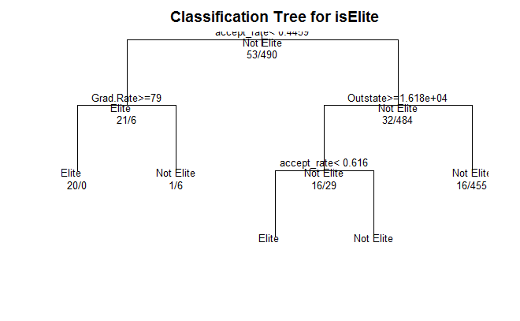

```r
plot(rp.tree, uniform=TRUE, main="Classification Tree for isElite")
text(rp.tree, use.n=TRUE, all=TRUE, cex=.8)
```

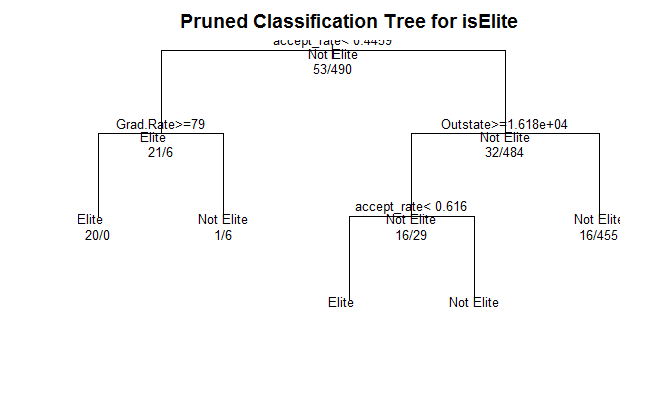

```r
#Pruning the tree
prp.tree <- prune(rp.tree, cp=rp.tree$cptable[which.min(rp.tree$cptable[,"xerror"]),"CP"])
plot(prp.tree, uniform=TRUE, main="Pruned Classification Tree for isElite")
text(prp.tree, use.n=TRUE, all=TRUE, cex=.8)
```

```
Classification tree:
rpart(formula = isElite ~ ., data = trainData)

Variables actually used in tree construction:
[1] accept_rate Grad.Rate   Outstate

Root node error: 53/543 = 0.097606

n= 543

       CP nsplit rel error  xerror    xstd
1 0.28302      0   1.00000 1.00000 0.13048
2 0.09434      1   0.71698 0.92453 0.12598
3 0.04717      2   0.62264 0.84906 0.12121
4 0.01000      4   0.52830 0.69811 0.11079
```

```
may not be applicable for this method
```

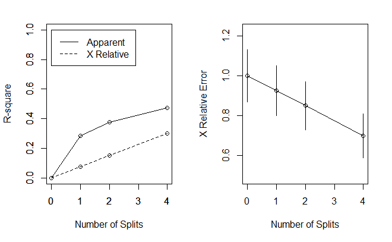

```r
par(mfrow=c(1,2))
rsq.rpart(rp.tree)
```

```r
library(factoextra)
library(ggplot2)
df <- na.omit(df)
df <- scale(df)
head(round(df,2))
```

```
     accept_rate Outstate Enroll Grad.Rate
[1,]       -0.03    -0.75  -0.06     -0.32
[2,]        0.91     0.46  -0.29     -0.55
[3,]        0.14     0.20  -0.48     -0.67
[4,]        0.61     0.63  -0.69     -0.38
[5,]        0.06    -0.72  -0.78     -2.94
[6,]        0.47     0.76  -0.67     -0.61
```

```r
set.seed(234)
km <- kmeans(df,2,nstart=25)
cat("____________________________________________________________________")
```

```
____________________________________________________________________
```

```r
cat("\n\n")
```

```r
print(km)
```

```
K-means clustering with 2 clusters of sizes 419, 358

Cluster means:
  accept_rate   Outstate     Enroll  Grad.Rate
1   0.1455959 -0.6638777  0.1855451 -0.6781741
2  -0.1704042  0.7769965 -0.2171604  0.7937289

Clustering vector:
  [1] 1 1 1 2 1 2 2 2 2 1 2 2 2 2 1 1 2 1 1 1 1 1 2 1 1 1 2 1 1 2 2 2 1 1 2 2
 [37] 2 2 2 1 2 2 1 1 2 1 1 2 2 1 1 1 1 1 2 1 2 1 1 2 2 1 1 2 2 1 1 1 2 1 2 2
 [73] 2 2 2 2 1 2 1 1 2 1 1 1 2 1 2 2 2 1 2 2 2 1 2 2 2 1 1 1 1 2 1 1 1 1 2 2
[109] 1 2 1 1 1 1 2 2 2 2 1 1 2 2 2 2 2 1 2 2 1 2 2 2 2 1 2 2 2 2 2 2 2 1 1 2
[145] 2 1 1 1 2 2 2 2 2 1 1 1 1 2 2 2 1 1 2 2 2 1 1 1 1 2 1 2 2 1 2 2 1 1 1 1
[181] 1 1 2 1 2 2 2 2 1 1 2 2 1 2 1 1 2 1 1 1 2 1 1 1 1 2 1 1 2 1 1 1 1 2 1 1
[217] 2 1 1 2 1 2 1 1 2 2 1 2 2 1 2 1 1 1 2 1 1 2 2 2 2 2 2 2 2 1 1 1 1 2 2 2
```

[output cut: 25 more lines]

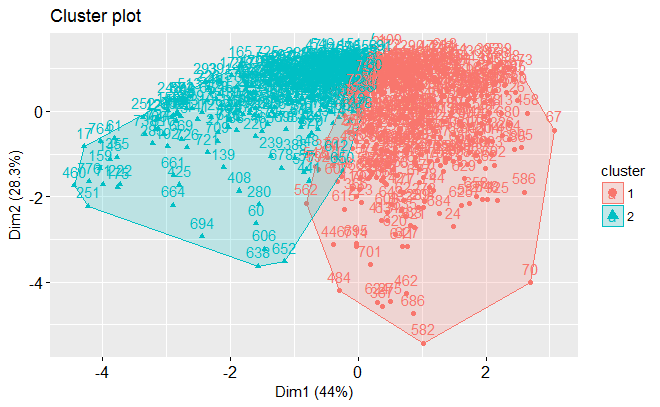

```r
fviz_cluster(km,data=df)
```

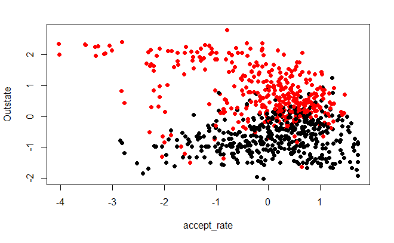

```r
plot(df, col = km$cluster, pch = 19)
points(km$cluter, col = 1:2, pch = 8, cex = 3)
```

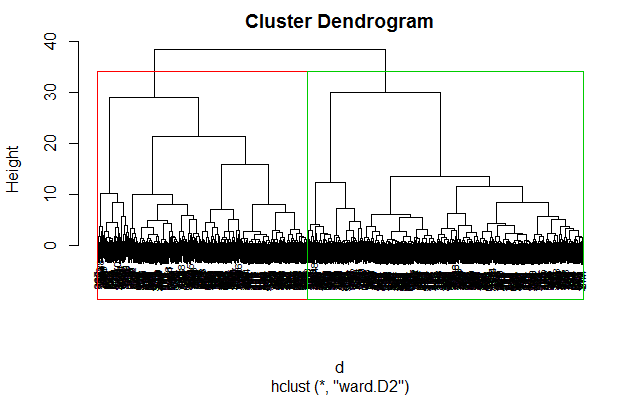

```r
#Hierarchial Clustering
#Creation of dissimilarity matrix
d <- dist(df,method = "euclidean")
#applying hclust() function
res_hc1 <- hclust(d, method = "ward.D2")
#Cutting groups into 4 clusters
grp1 <- cutree(res_hc1,k=2)
#Plotting the cluster
plot(res_hc1, cex = 0.6)
rect.hclust(res_hc1, k = 2, border = 2:5)
```

```
  cluster size ave.sil.width
1       1  441          0.34
2       2  336          0.13
```

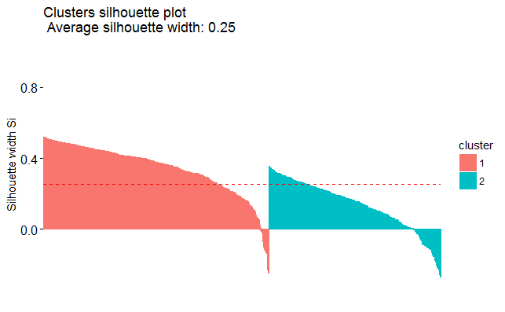

```r
res.hc1 <- eclust(df, "hclust", k = 2, graph = FALSE)
fviz_silhouette(res.hc1)
```

After applying clustering on the college dataset, obervation is that clustering is not appropriate to determine ifnormation from dataset because clusters are not clear and crisp that can provide resourceful instances.